# TCC - Modelo T3 Reduzido (Análise de Agrupamentos e ACM) - ENEM Roraima

Adriana Melges Q Weingart

Setembro 2022

# 1 Análise de Agrupamentos e ACM: Dados do ENEM 2020

## 1.1 Dataset

Microdados do ENEM 2020, disponíveis na página do [Ministério da Educação - Instituto Nacional de Estudos e Pesquisas Educacionais Anísio Teixeira | Inep - ENEM](https://www.gov.br/inep/pt-br/acesso-a-informacao/dados-abertos/microdados/enem).

## 1.2 Bibliotecas

```r
library(tidyverse)
library(kableExtra)
library(knitr)
library(tictoc)
library(factoextra)
library(cabootcrs)
library(FactoMineR)
library(ggrepel)
library(gridExtra)
```

## 1.3 Loading Data

Carregando o dataset de Microdados do Enem de 2020 Dataset: ENEM2020

```r
ENEM2020 <- read_delim("MICRODADOS_ENEM_2020.csv", delim = ";")
```

## 1.4 Cleaning Data

### 1.4.1 Selecionando apenas dados do estado de RR - para efeitos do estudo inicial

*Este passo será substituido ao executar em ambiente de cloud, com mais poder de processamento*

Selecionando apenas o Estado de RR, baseado nos resultados da Análise Exploratória da base de dados do ENEM2020

```r
ENEM2020[ENEM2020$SG_UF_PROVA == 'RR', ] -> ENEM
```

### 1.4.2 Removendo as entradas dos participantes que faltaram alguma das provas

```r
ENEM[ENEM$TP_PRESENCA_CN == '1' &
     ENEM$TP_PRESENCA_CH == '1' &
     ENEM$TP_PRESENCA_LC == '1' &
     ENEM$TP_PRESENCA_MT == '1', ] -> ENEM
```

### 1.4.3 Removendo as colunas listadas acima como não necessárias para o estudo

```r
ENEM <- select(ENEM, -c(TP_ENSINO,
                        CO_MUNICIPIO_ESC,
                        NO_MUNICIPIO_ESC,
                        CO_UF_ESC,
                        SG_UF_ESC,
                        TP_DEPENDENCIA_ADM_ESC,
                        TP_LOCALIZACAO_ESC,
                        TP_SIT_FUNC_ESC,
                        TP_PRESENCA_CN,
                        TP_PRESENCA_CH,
                        TP_PRESENCA_LC,
                        TP_PRESENCA_MT,
                        NU_ANO,
                        CO_MUNICIPIO_PROVA,
                        NO_MUNICIPIO_PROVA,
                        CO_UF_PROVA,
                        CO_PROVA_CN,
                        CO_PROVA_CH,
                        CO_PROVA_LC,
                        CO_PROVA_MT,
                        TX_RESPOSTAS_CN,
                        TX_RESPOSTAS_CH,
                        TX_RESPOSTAS_LC,
                        TX_RESPOSTAS_MT,
                        TX_GABARITO_CN,
                        TX_GABARITO_CH,
                        TX_GABARITO_LC,
                        TX_GABARITO_MT))
```

### 1.4.4 Verificando NAs no dataset

```r
colSums(is.na(ENEM))
```

```
##      NU_INSCRICAO   TP_FAIXA_ETARIA           TP_SEXO   TP_ESTADO_CIVIL
##                 0                 0                 0                 0
##       TP_COR_RACA  TP_NACIONALIDADE   TP_ST_CONCLUSAO   TP_ANO_CONCLUIU
##                 0                 0                 0                 0
##         TP_ESCOLA      IN_TREINEIRO       SG_UF_PROVA        NU_NOTA_CN
##                 0                 0                 0                 0
##        NU_NOTA_CH        NU_NOTA_LC        NU_NOTA_MT         TP_LINGUA
##                 0                 0                 0                 0
## TP_STATUS_REDACAO     NU_NOTA_COMP1     NU_NOTA_COMP2     NU_NOTA_COMP3
##                 0                 0                 0                 0
##     NU_NOTA_COMP4     NU_NOTA_COMP5   NU_NOTA_REDACAO              Q001
##                 0                 0                 0                14
##              Q002              Q003              Q004              Q005
##                14                14                14                14
##              Q006              Q007              Q008              Q009
##                14                14                14                14
##              Q010              Q011              Q012              Q013
##                14                14                14                14
##              Q014              Q015              Q016              Q017
##                14                14                14                14
##              Q018              Q019              Q020              Q021
##                14                14                14                14
##              Q022              Q023              Q024              Q025
##                14                14                14                14
```

### 1.4.5 Removendo NAs:

```r
ENEM <- na.omit(ENEM)
```

### 1.4.6 Verificando notas zero em alguma prova / participante

```r
count(ENEM[ENEM$NU_NOTA_CN == 0.0 |
      ENEM$NU_NOTA_CH == 0.0 |
      ENEM$NU_NOTA_LC == 0.0 |
      ENEM$NU_NOTA_MT == 0.0 |
      ENEM$NU_NOTA_REDACAO == 0.0  ,]) -> zero_provas
```

204 participantes zeraram em alguma prova.

**Alunos que zeraram nas Provas Objetivas:**

14 participantes zeraram em Provas Objetivas:  
- Ciências da Natureza  
- Ciências Humanas  
- Linguagens e Códigos  
- Matemática

Apesar de várias informações publicadas na internet (como o Guia da Carreira, na publicação disponível no link: https://www.guiadacarreira.com.br/educacao/motivos-para-zerar-o-enem/) dizerem que “não dá para tirar zero nas provas objetivas do ENEM”, há 14 entradas com participantes que zeraram em alguma das 4 provas objetivas (Ciências da Natureza, Ciências Humanas, Linguagens e Códigos e Matemática)

Estas entradas, durante a análise, se comportariam como outliers, afetando os resultados. Portanto, ara efeito desta análise, estas entradas serão descartadas.

**Alunos que zeraram na Redação:**

193 participantes zeraram na Redação.

Considerando este fato, e os motivos que levam ao “zero”, assume-se que nenhum estudante deseja zerar na redação.

Para efeito desta análise, estas entradas serão descartadas.

### 1.4.7 Removendo alunos que zeraram em alguma prova

```r
ENEM[ENEM$NU_NOTA_CN != 0.0 &
     ENEM$NU_NOTA_CH != 0.0 &
     ENEM$NU_NOTA_LC != 0.0 &
     ENEM$NU_NOTA_MT != 0.0 &
     ENEM$NU_NOTA_REDACAO != 0.0  ,] -> ENEM
```

## 1.5 Análise de Cluster / Agrupamento

```r
dist_ENEM <- dist(ENEM[ , c(12:15, 23)], method = "euclidean")
```

### 1.5.1 Definindo o cluster

**métodos considerados para agrupamento “single”, “complete” e “average”**

```r
cluster_single <- hclust(dist_ENEM, method = "single" )
cluster_complete <- hclust(dist_ENEM, method = "complete" )
cluster_average <- hclust(dist_ENEM, method = "average" )
```

**métodos considerados para identificar quantidade de agrupamentos: “elbow” (wss), “silhouette” e “gap_stat”**

#### 1.5.1.1 Método “elbow” (method = “wss”)

FUN = hcut > Hierarchical Cluster

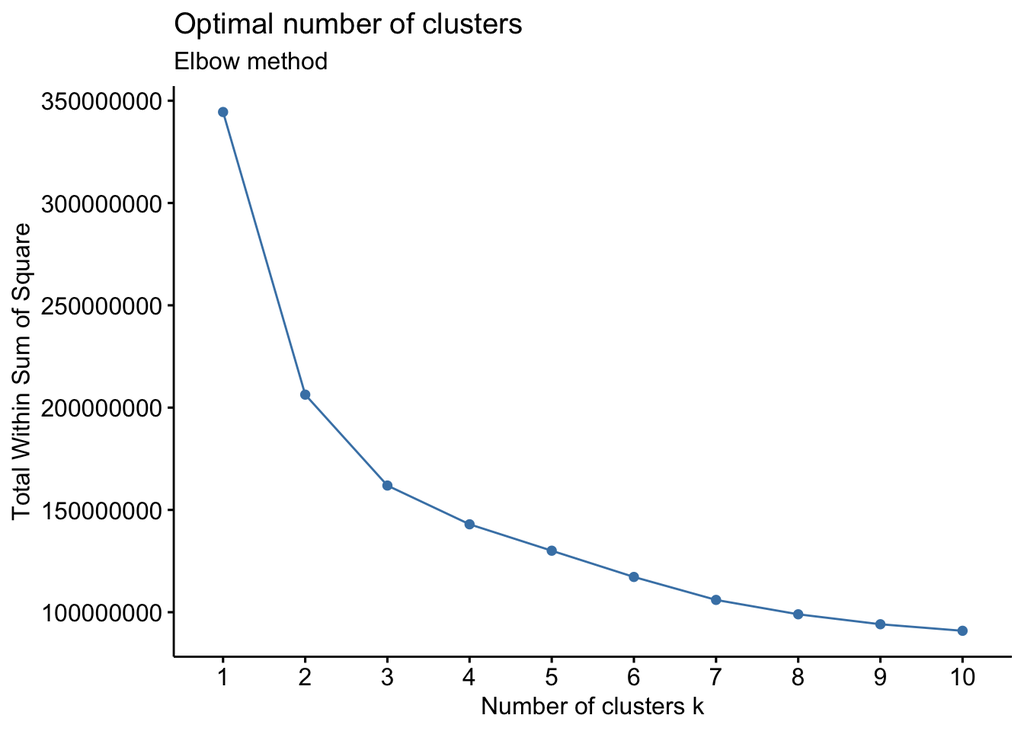

```r
fviz_nbclust(ENEM[ , c(12:15, 23)], FUN = hcut, method = "wss") +
            labs(subtitle = "Elbow method")
```

O “Elbow” no método elbow acontece (visualmente) entre 2, 3 e 4.

#### 1.5.1.2 Método “silhouette” (method = “silhouette”)

FUN = hcust

[output not shown]

#### 1.5.1.3 Gap Statistic Method (method = “gap_stat”)

FUN = hcut

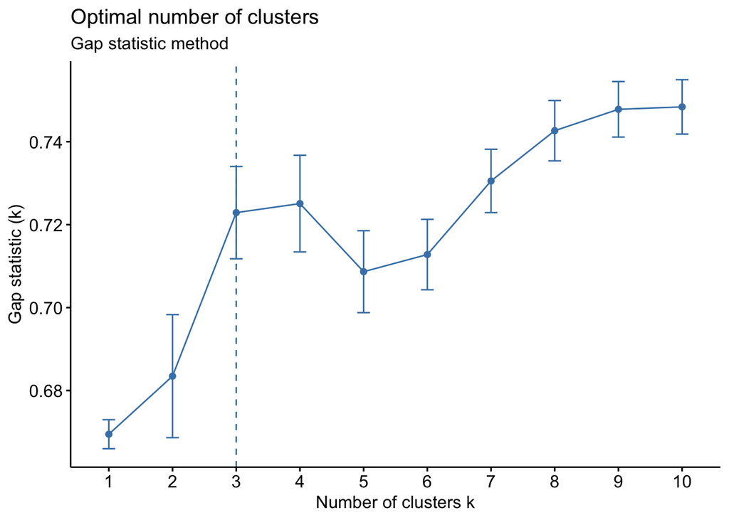

```r
fviz_nbclust(ENEM[ , c(12:15, 23)], FUN = hcut, nstart = 25,  method = "gap_stat", nboot = 50) +
  labs(subtitle = "Gap statistic method")
```

O Método Gap Statistic aponta 3 como o número ideal de custers.

Portanto, adotando 3 agrupamentos.

### 1.5.2 Calculando os agrupamentos

```r
grupos <- cutree(cluster_complete, k = 3)
table(grupos)
```

```
## grupos
##    1    2    3
## 3736 1661  584
```

**transformando em data frame a saida do cluster, e join com o dataset original**

```r
notas_grupos <- data.frame(grupos)
ENEM <- cbind(ENEM, notas_grupos)
```

### 1.5.3 Análise Descritiva

#### 1.5.3.1 Média das variáveis por grupo

```r
Notas_Medias_por_grupo <- ENEM %>%
  group_by(grupos) %>%
  summarise(n = n(),
            nota_ciencias_natureza = mean(NU_NOTA_CN),
            nota_ciencias_humanas = mean(NU_NOTA_CH),
            nota_linguagens_e_codigos = mean(NU_NOTA_LC),
            nota_matematica = mean(NU_NOTA_MT),
            nota_redacao = mean(NU_NOTA_REDACAO)
  )
Notas_Medias_por_grupo %>%
  kable() %>%
  kable_styling(bootstrap_options = "striped",
                full_width = T,
                font_size = 12)
```

| grupos | n | nota_ciencias_natureza | nota_ciencias_humanas | nota_linguagens_e_codigos | nota_matematica | nota_redacao |
| --- | --- | --- | --- | --- | --- | --- |
| 1 | 3736 | 458.9146 | 483.5769 | 501.7793 | 462.4005 | 502.8640 |
| 2 | 1661 | 549.6879 | 580.5204 | 569.2211 | 592.3067 | 748.7297 |
| 3 | 584 | 414.9567 | 404.0820 | 449.0849 | 417.7132 | 321.7808 |

## 1.6 Análise por Correspondência Múltipla (ACM)

Considerando as variáveis socioeconômicas:  
* Q021: Participante tem TV por assinatura em casa (sim/não)  
* Q024: Participante tem computador me casa (sim/não)  
* Q025: Participante tem acesso à internet em casa (sim/não)  
* grupos: clusters criados durante a Análise de Agrupamentos.

```r
ENEM_socioecon <- select(ENEM, c(Q021, Q024, Q025, grupos))

colnames(ENEM_socioecon) <- c("tv_assinatura",
                              "computador",
                              "internet",
                              "cluster")

ENEM_socioecon["tv_assinatura"][ENEM_socioecon["tv_assinatura"] == "A"] <- "não"
ENEM_socioecon["tv_assinatura"][ENEM_socioecon["tv_assinatura"] == "B"] <- "sim"

ENEM_socioecon["computador"][ENEM_socioecon["computador"] == "A"] <- "não"
ENEM_socioecon["computador"][ENEM_socioecon["computador"] == "B" |
                               ENEM_socioecon["computador"] == "C" |
                               ENEM_socioecon["computador"] == "D" |
                               ENEM_socioecon["computador"] == "E"] <- "sim"

ENEM_socioecon["internet"][ENEM_socioecon["internet"] == "A"] <- "não"
ENEM_socioecon["internet"][ENEM_socioecon["internet"] == "B"] <- "sim"
```

### 1.6.1 QUI2 Test

#### 1.6.1.1 Variáveis tv_assinatura vs computador

```r
tab_tvassinaturaXcomputador <- table(ENEM_socioecon$tv_assinatura,
                                     ENEM_socioecon$computador)
tab_tvassinaturaXcomputador
```

```
##
##        não  sim
##   não 2687 2253
##   sim  213  828
```

```r
qui2_tvassinaturaXcomputador <- chisq.test(tab_tvassinaturaXcomputador)
qui2_tvassinaturaXcomputador
```

```
##
##  Pearson's Chi-squared test with Yates' continuity correction
##
## data:  tab_tvassinaturaXcomputador
## X-squared = 394.99, df = 1, p-value < 0.00000000000000022
```

#### 1.6.1.2 Variáveis tv_assinatura vs internet

```r
tab_tvassinaturaXinternet <- table(ENEM_socioecon$tv_assinatura,
                                   ENEM_socioecon$internet)
tab_tvassinaturaXinternet
```

```
##
##        não  sim
##   não 1402 3538
##   sim   42  999
```

```r
qui2_tvassinaturaXinternet <- chisq.test(tab_tvassinaturaXinternet)
qui2_tvassinaturaXinternet
```

```
##
##  Pearson's Chi-squared test with Yates' continuity correction
##
## data:  tab_tvassinaturaXinternet
## X-squared = 276.94, df = 1, p-value < 0.00000000000000022
```

#### 1.6.1.3 Variáveis tv_assinatura vs cluster de participantes

```r
tab_tvassinaturaXcluster <- table(ENEM_socioecon$tv_assinatura,
                                  ENEM_socioecon$cluster)
tab_tvassinaturaXcluster
```

```
##
##          1    2    3
##   não 3209 1203  528
##   sim  527  458   56
```

```r
qui2_tvassinaturaXcluster <- chisq.test(tab_tvassinaturaXcluster)
qui2_tvassinaturaXcluster
```

```
##
##  Pearson's Chi-squared test
##
## data:  tab_tvassinaturaXcluster
## X-squared = 172.58, df = 2, p-value < 0.00000000000000022
```

#### 1.6.1.4 Variáveis computador vs internet

```r
tab_computadorXinternet <- table(ENEM_socioecon$computador,
                                 ENEM_socioecon$internet)
tab_computadorXinternet
```

```
##
##        não  sim
##   não 1196 1704
##   sim  248 2833
```

```r
qui2_computadorXinternet <- chisq.test(tab_computadorXinternet)
qui2_computadorXinternet
```

```
##
##  Pearson's Chi-squared test with Yates' continuity correction
##
## data:  tab_computadorXinternet
## X-squared = 896.85, df = 1, p-value < 0.00000000000000022
```

#### 1.6.1.5 Variáveis computador vs cluster de participantes

```r
tab_computadorXcluster <- table(ENEM_socioecon$computador,
                                ENEM_socioecon$cluster)
tab_computadorXcluster
```

```
##
##          1    2    3
##   não 2024  477  399
##   sim 1712 1184  185
```

```r
qui2_computadorXcluster <- chisq.test(tab_computadorXcluster)
qui2_computadorXcluster
```

```
##
##  Pearson's Chi-squared test
##
## data:  tab_computadorXcluster
## X-squared = 400.3, df = 2, p-value < 0.00000000000000022
```

#### 1.6.1.6 Variáveis internet vs cluster de participantes

```r
tab_internetXcluster <- table(ENEM_socioecon$internet,
                              ENEM_socioecon$cluster)
tab_internetXcluster
```

```
##
##          1    2    3
##   não 1031  202  211
##   sim 2705 1459  373
```

```r
qui2_internetXcluster <- chisq.test(tab_internetXcluster)
qui2_internetXcluster
```

```
##
##  Pearson's Chi-squared test
##
## data:  tab_internetXcluster
## X-squared = 200.35, df = 2, p-value < 0.00000000000000022
```

### 1.6.2 Matriz binária

```r
matriz_binaria <- getindicator(Xinput = ENEM_socioecon)
#matriz_binaria
#CA(matriz_binaria)
```

### 1.6.3 Matriz de Burt

```r
matriz_burt <- getBurt(Xinput = ENEM_socioecon)
#matriz_burt
#CA(matriz_burt)
```

### 1.6.4 Rodando a ACM

#### 1.6.4.1 Coordenadas de cada categoria

*componente var$coord do objeto ACM_ENEM*

```r
round(ACM_ENEM$var$coord, 3) %>%
  kable() %>%
  kable_styling(bootstrap_options = "striped",
                full_width = T,
                font_size = 12)
```

|  | Dim 1 | Dim 2 | Dim 3 | Dim 4 | Dim 5 |
| --- | --- | --- | --- | --- | --- |
| tv_assinatura_não | -0.272 | -0.036 | -0.131 | -0.343 | 0.031 |
| tv_assinatura_sim | 1.290 | 0.173 | 0.621 | 1.626 | -0.147 |
| computador_não | -0.786 | 0.031 | -0.097 | 0.247 | -0.611 |
| computador_sim | 0.740 | -0.029 | 0.091 | -0.233 | 0.575 |
| internet_não | -1.247 | 0.056 | -0.550 | 0.757 | 0.842 |
| internet_sim | 0.397 | -0.018 | 0.175 | -0.241 | -0.268 |
| 1 | -0.260 | -0.622 | 0.378 | 0.017 | 0.058 |
| 2 | 0.877 | 0.462 | -1.253 | 0.075 | -0.208 |
| 3 | -0.829 | 2.664 | 1.144 | -0.319 | 0.221 |

#### 1.6.4.2 Inércias Principais

*componente $eig do objeto ACM_ENEM*

```r
ACM_ENEM$eig
```

```
##       eigenvalue percentage of variance cumulative percentage of variance
## dim 1  0.4374798               34.99838                          34.99838
## dim 2  0.2503973               20.03178                          55.03016
## dim 3  0.2099583               16.79666                          71.82683
## dim 4  0.2021667               16.17334                          88.00017
## dim 5  0.1499979               11.99983                         100.00000
```

### 1.6.5 Percentual da Inércia Principal explicada por Dimensão

#### 1.6.5.1 Número de Categorias por Variável

```r
categorias <- apply(ENEM_socioecon,
                    MARGIN =  2,
                    FUN = function(x) nlevels(as.factor(x)))
```

#### 1.6.5.2 Inércia Total Explicada

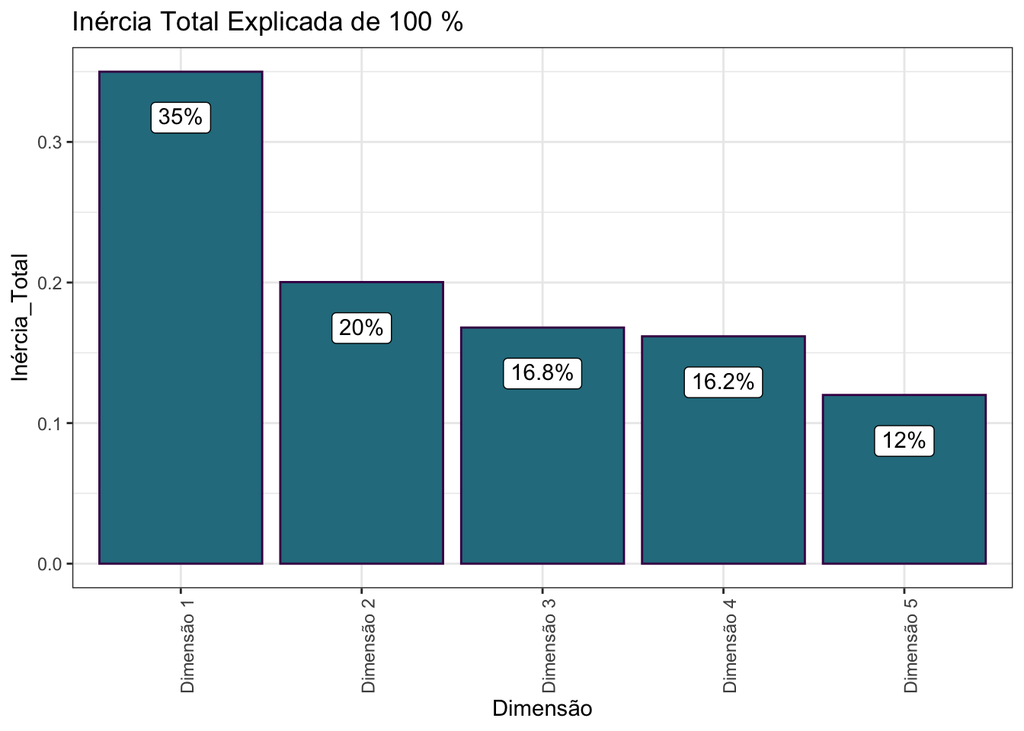

```r
inercia_total <- (sum(categorias) - length(categorias)) / length(categorias)
# inercia_total

#sum(ACM_ENEM$eig[,1])

inercia_total_explicada <- ACM_ENEM$eig[,1] / sum(ACM_ENEM$eig[,1])

data.frame(Dimensão = paste("Dimensão", 1:length(inercia_total_explicada)),
           Inércia_Total = inercia_total_explicada) %>%
  ggplot(aes(x = Dimensão,
             y = Inércia_Total,
             label = paste0(round(Inércia_Total,3)*100,"%"))) +
  geom_bar(stat = "identity",
           color = "#440154FF",
           fill = "#287C8EFF") +
  geom_label(vjust = 2) +
  labs(title = paste("Inércia Total Explicada de",
                     paste0(sum(inercia_total_explicada) * 100),"%")) +
  theme_bw() +
  theme(axis.text.x = element_text(angle = 90))
```

#### 1.6.5.3 Mapa Perceptual

```r
ACM_ENEM_df <- data.frame(ACM_ENEM$var$coord, Variável = rep(names(categorias), categorias))

ACM_ENEM_df %>%
  rownames_to_column() %>%
  rename(Categoria = 1) %>%
  mutate(Categoria = gsub("perfil.","", Categoria),
         Categoria = gsub("aplicacao.","", Categoria),
         Categoria = gsub("estado_civil.","", Categoria)) %>%
  kable() %>%
  kable_styling(bootstrap_options = "striped",
                full_width = T,
                font_size = 12)
```

| Categoria | Dim.1 | Dim.2 | Dim.3 | Dim.4 | Dim.5 | Variável |
| --- | --- | --- | --- | --- | --- | --- |
| tv_assinatura_não | -0.2718835 | -0.0364270 | -0.1309509 | -0.3426001 | 0.0309549 | tv_assinatura |
| tv_assinatura_sim | 1.2902063 | 0.1728620 | 0.6214192 | 1.6257871 | -0.1468944 | tv_assinatura |
| computador_não | -0.7861747 | 0.0306724 | -0.0971096 | 0.2470541 | -0.6106851 | computador |
| computador_sim | 0.7399892 | -0.0288705 | 0.0914047 | -0.2325404 | 0.5748091 | computador |
| internet_não | -1.2465076 | 0.0555681 | -0.5503476 | 0.7574186 | 0.8417437 | internet |
| internet_sim | 0.3967284 | -0.0176858 | 0.1751602 | -0.2410651 | -0.2679034 | internet |
| 1 | -0.2601603 | -0.6216291 | 0.3783504 | 0.0166028 | 0.0581316 | cluster |
| 2 | 0.8766851 | 0.4616061 | -1.2530833 | 0.0746870 | -0.2083029 | cluster |
| 3 | -0.8291352 | 2.6638329 | 1.1435859 | -0.3186357 | 0.2205675 | cluster |

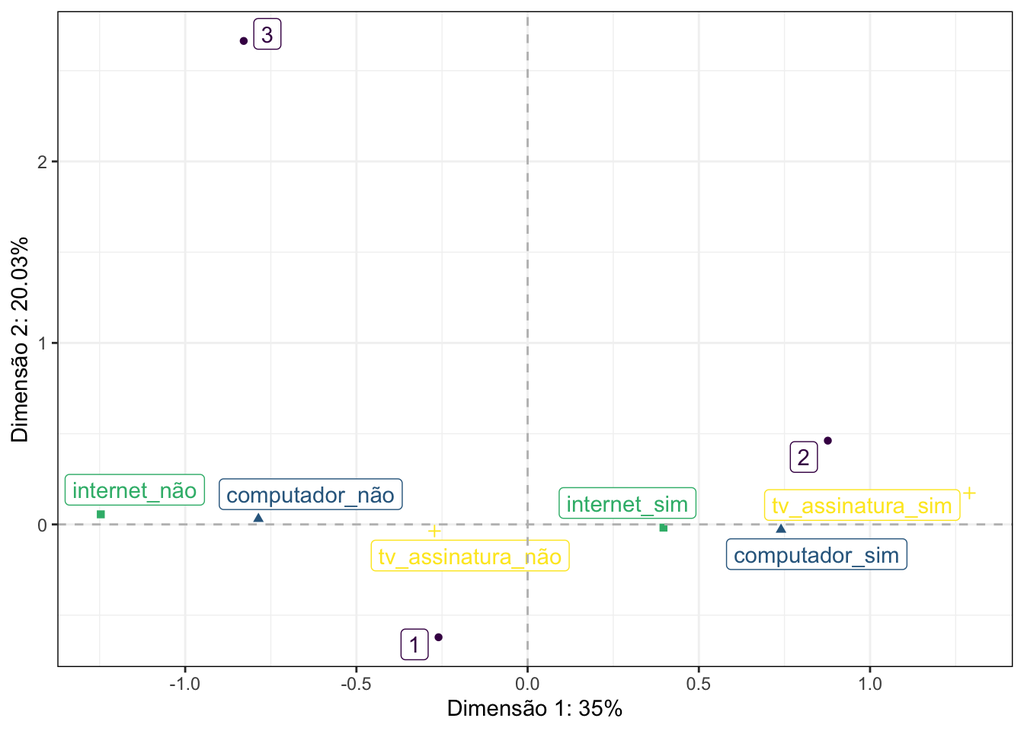

```r
#ggplotly(
ACM_ENEM_df %>%
  rownames_to_column() %>%
  rename(Categoria = 1) %>%
  ggplot(aes(x = Dim.1,
             y = Dim.2,
             label = Categoria,
             color = Variável,
             shape = Variável)) +
  geom_point() +
  geom_label_repel() +
  geom_vline(aes(xintercept = 0), linetype = "dashed", color = "grey") +
  geom_hline(aes(yintercept = 0), linetype = "dashed", color = "grey") +
  labs(x = paste("Dimensão 1:", paste0(round(ACM_ENEM$eig[1,2], 2), "%")),
       y = paste("Dimensão 2:", paste0(round(ACM_ENEM$eig[2,2], 2), "%"))) +
  scale_color_viridis_d() +
  theme(panel.background = element_rect("white"),
        panel.border = element_rect("NA"),
        panel.grid = element_line("gray95"),
        legend.position = "none") -> GRAFICO_Mapa_Perceptual
#)

GRAFICO_Mapa_Perceptual
```

## 1.7 Análise dos Agrupamentos vs Variáveis Socioeconômicas

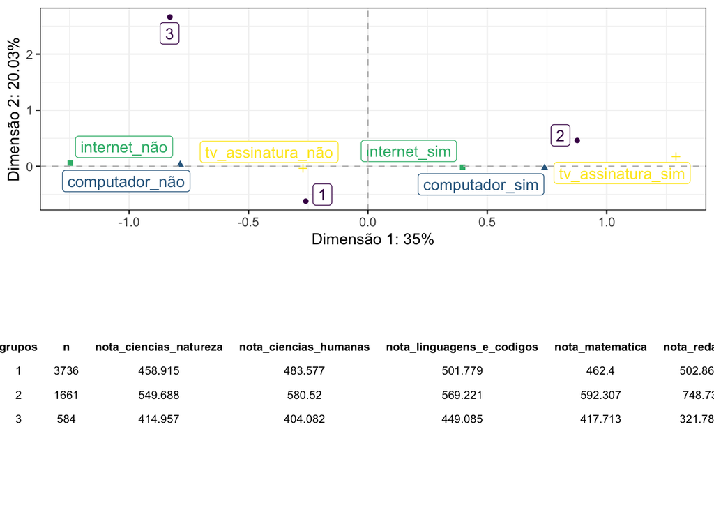

```r
TableGrob_Notas_Medias_por_grupo <- tableGrob(round(Notas_Medias_por_grupo, digits = 3),
                                              theme=ttheme_minimal(base_size = 8))
grid.arrange(GRAFICO_Mapa_Perceptual, TableGrob_Notas_Medias_por_grupo, ncol = 1)
```

## 1.8 Conclusão

Com base no Mapa Perceptual acima pode-se verificar que o grupo 2 (melhores médias em todas as provas) apresenta forte associação com as categorias “internet_sim”, “computador_sim” e “tv_assinatura_sim”.

Já o grupo 3 (médias mais baixas em todas as provas) não tem associal próxima a nenhuma das outras categorias.

Dos dados apresentados, não é possível estabelecer relação de causa-e-efeito, como por exemplo, se as notas do grupo 2 são melhores porque os participantes classificados neste grupo tem mais acesso à informação; ou ainda, se os participantes deste grupo tem um poder aquisitivo maior, que lhes permite ter acesso à TV por assinatura, Computador e Internet em casa, e por consequência a uma melhor educação ou preparação também - o que não aparece para os participantes do grupo 1.

Para poder aprofundar esta análise, e talvez investigar as razões para essas associações, outros dados precisariam ser analisados, como: * renda familiar;  
* tipo de escola;

Para esta análise, fica apenas a identificação de que notas maiores no ENEM estão associadas aos participantes que tem TV por assinatura, Computador e Internet em casa. Mas, reforçando, não há como estabelecer relação de causa-e-efeito apenas com os dados analisados.

## 1.9 Tempo de Execução

```r
TOTAL_DL <- c(TOTAL_DL$msg, TOTAL_DL$toc - TOTAL_DL$tic)
TOTAL_DW <- c(TOTAL_DW$msg, TOTAL_DW$toc - TOTAL_DW$tic)
TOTAL_AC <- c(TOTAL_AC$msg, TOTAL_AC$toc - TOTAL_AC$tic)
TOTAL_ACM <- c(TOTAL_ACM$msg, TOTAL_ACM$toc - TOTAL_ACM$tic)
TOTAL <- c(TOTAL$msg, TOTAL$toc - TOTAL$tic)

tempos <- data.frame(c(TOTAL_DL[1], TOTAL_DL[2]),
                     c(TOTAL_DW[1], TOTAL_DW[2]),
                     c(TOTAL_AC[1], TOTAL_AC[2]),
                     c(TOTAL_ACM[1], TOTAL_ACM[2]),
                     c(TOTAL[1], TOTAL[2]))

tempos %>%
  purrr::set_names(as.character(slice(., 1))) %>%
  slice(-1) -> tempos

data.frame(t(tempos)) -> tempos

tempos$elapsed <- as.numeric(tempos$elapsed)

tempos %>%
  kable() %>%
  kable_styling(bootstrap_options = "striped",
                full_width = F,
                font_size = 12)
```

|  | elapsed |
| --- | --- |
| total_dataloading | 488.194 |
| total_datawrangling | 11.116 |
| total_analisecluster | 2627.516 |
| total_acm | 4.599 |
| total | 3131.574 |